# ml4econ Shrinkage Methods

Dor Meir

may 7 2019

## Part 1: Explore glmnet

1. Install package and import library “glmnet” for shrinkage method functions.

```r
#install.packages("glmnet", repos = "http://cran.us.r-project.org")
library("glmnet")
```

2. We will use the Credit dataset. Load it from folder N, view it…

```r
#install.packages("ISLR", repos = "http://cran.us.r-project.org")
library(ISLR)
dat<-Credit
attach(dat)
#View(dat)
#summary(dat)
str(dat)
```

```
## 'data.frame':    400 obs. of  12 variables:
##  $ ID       : int  1 2 3 4 5 6 7 8 9 10 ...
##  $ Income   : num  14.9 106 104.6 148.9 55.9 ...
##  $ Limit    : int  3606 6645 7075 9504 4897 8047 3388 7114 3300 6819 ...
##  $ Rating   : int  283 483 514 681 357 569 259 512 266 491 ...
##  $ Cards    : int  2 3 4 3 2 4 2 2 5 3 ...
##  $ Age      : int  34 82 71 36 68 77 37 87 66 41 ...
##  $ Education: int  11 15 11 11 16 10 12 9 13 19 ...
##  $ Gender   : Factor w/ 2 levels " Male","Female": 1 2 1 2 1 1 2 1 2 2 ...
##  $ Student  : Factor w/ 2 levels "No","Yes": 1 2 1 1 1 1 1 1 1 2 ...
##  $ Married  : Factor w/ 2 levels "No","Yes": 2 2 1 1 2 1 1 1 1 2 ...
##  $ Ethnicity: Factor w/ 3 levels "African American",..: 3 2 2 2 3 3 1 2 3 1 ...
##  $ Balance  : int  333 903 580 964 331 1151 203 872 279 1350 ...
```

…and check for NA’s and irrelevant variables:

```r
length(which(is.na(dat)))
```

```
## [1] 0
```

–> There are no missing values (0 length vector of missing values)

3. Prepare data: glmnet accepts data in matrix form, with quantitative variables only, and no missing values. Use model.matrix() to prepare the data for modelling. We will be predicting Income using all available predictors, therefore our formula will be Income~. . *hint: notice model.matrix() creates an intercept column. Get rid of this column before modelling.

find non-quantitative variables:

```r
colnames(dat[,sapply(dat,class)=="factor"])
```

```
## [1] "Gender"    "Student"   "Married"   "Ethnicity"
```

```r
dat1 <- model.matrix(Income~., data = dat)
dat1 <- dat1[,-1]
head(dat1)
```

```
##   ID Limit Rating Cards Age Education GenderFemale StudentYes MarriedYes
## 1  1  3606    283     2  34        11            0          0          1
## 2  2  6645    483     3  82        15            1          1          1
## 3  3  7075    514     4  71        11            0          0          0
## 4  4  9504    681     3  36        11            1          0          0
## 5  5  4897    357     2  68        16            0          0          1
## 6  6  8047    569     4  77        10            0          0          0
##   EthnicityAsian EthnicityCaucasian Balance
## 1              0                  1     333
## 2              1                  0     903
## 3              1                  0     580
## 4              1                  0     964
## 5              0                  1     331
## 6              0                  1    1151
```

4. Run lasso, ridge, and elastic net models. Define each model by a name that specifies the model type. *Run two elastic net models for two different alphas. Choose an alpha close to zero, and a second alpha closer to 1.

The predicted variable y and the standardized predictors x:

```r
y <- dat1[Income]
x <- scale(dat1[,-Income])
```

### Lasso

```r
lasso <- glmnet(x,y,alpha=1)
```

### Ridge

```r
ridge <- glmnet(x,y,alpha=0)
```

### Elastic: close to ridge alpha

```r
elastic_net1 <- glmnet(x,y,alpha=0.01)
```

### Elastic: close to lasso alpha

```r
elastic_net2 <- glmnet(x,y,alpha=0.9)
```

5. Use coef(model) to view the coefficients across the lambdas for the different models. What happens to the coefficients as lambda gets smaller? How does this differ for the different methods?

I’ll plot the coeffiecient to log lambda (in the top axis is the number of non-zero coefficients):

```r
print("Lasso:")
```

```
## [1] "Lasso:"
```

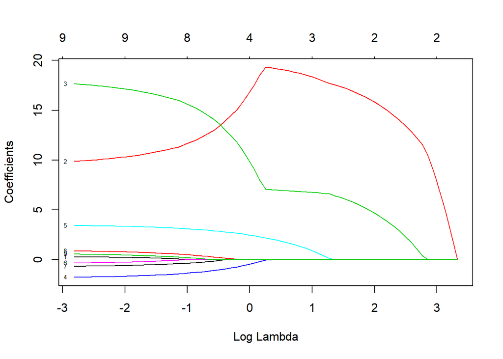

```r
plot(lasso,xvar="lambda",label=TRUE)
```

```r
print("Ridge:")
```

```
## [1] "Ridge:"
```

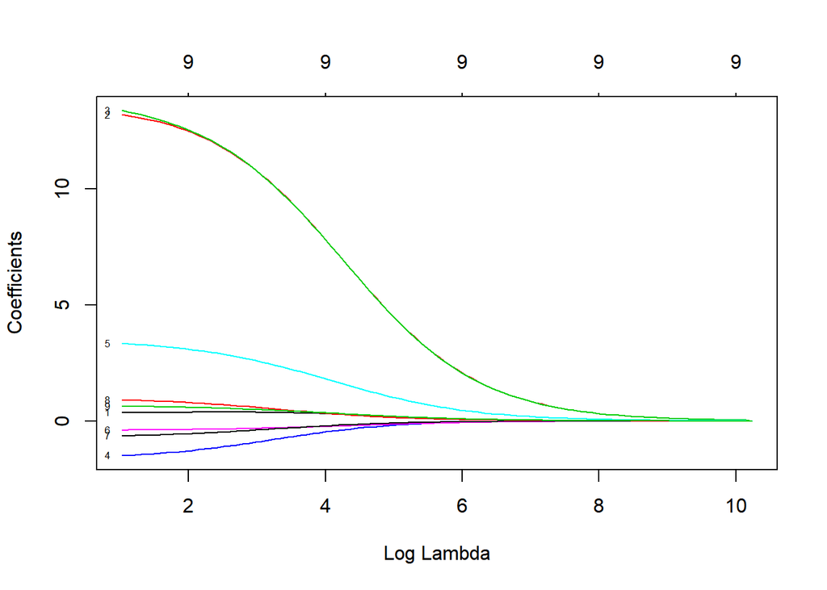

```r
plot(ridge,xvar="lambda",label=TRUE)
```

```r
print("Elastic net 1:")
```

```
## [1] "Elastic net 1:"
```

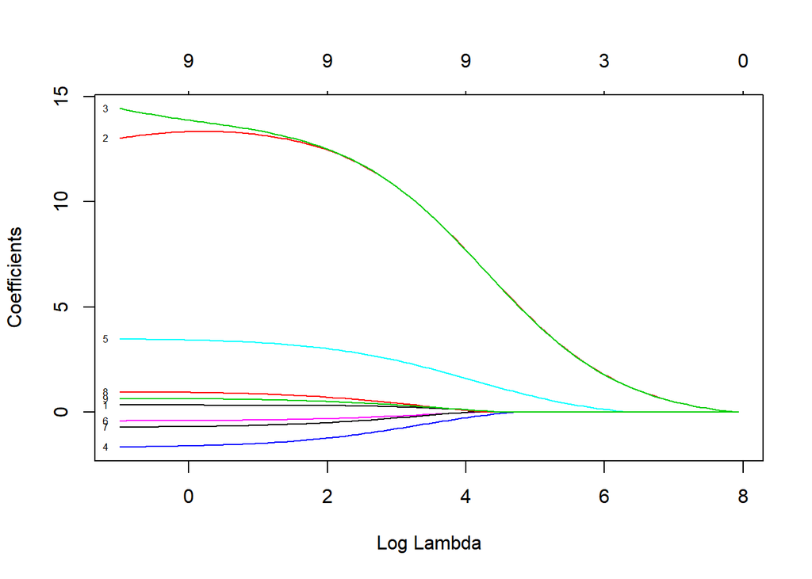

```r
plot(elastic_net1,xvar="lambda",label=TRUE)
```

```r
print("Elastic net 2:")
```

```
## [1] "Elastic net 2:"
```

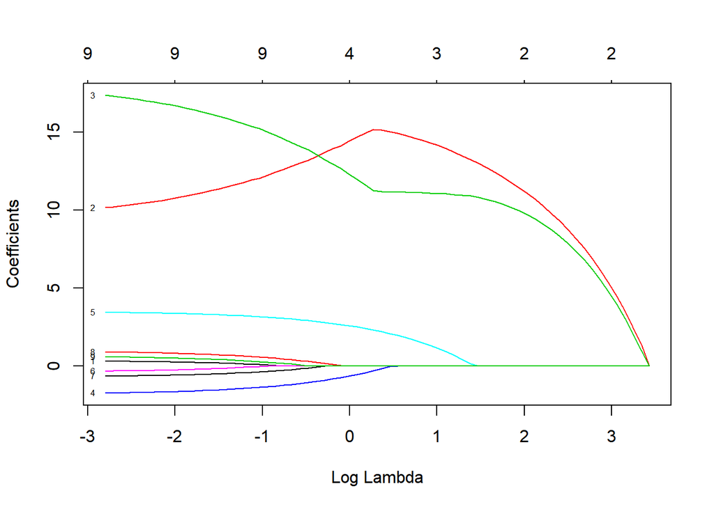

```r
plot(elastic_net2,xvar="lambda",label=TRUE)
```

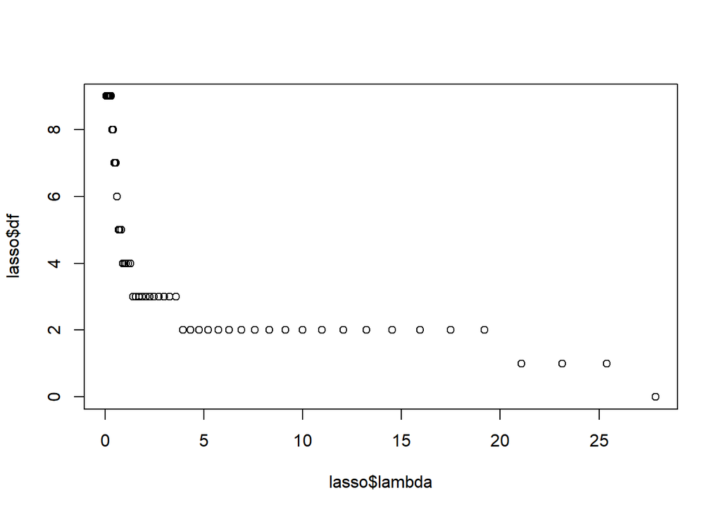

```r
plot(lasso$lambda,lasso$df)
```

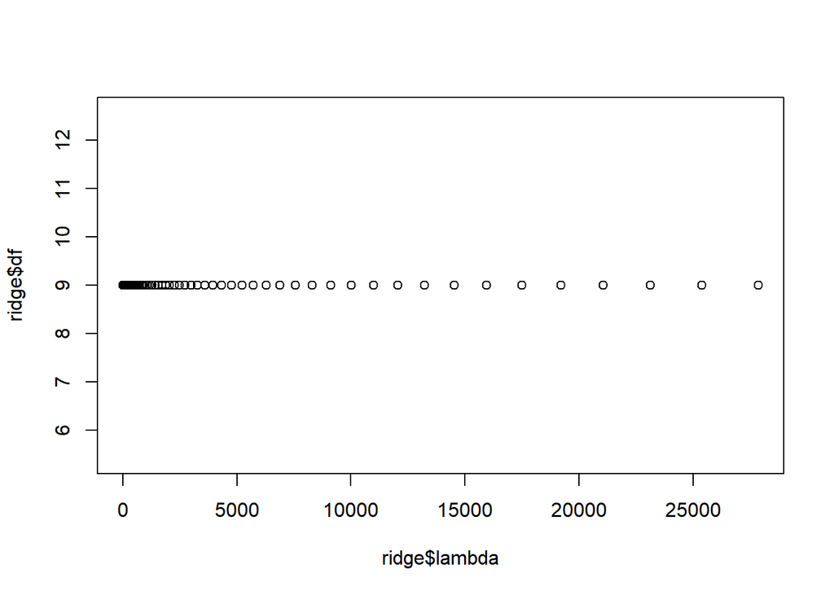

```r
plot(ridge$lambda,ridge$df)
```

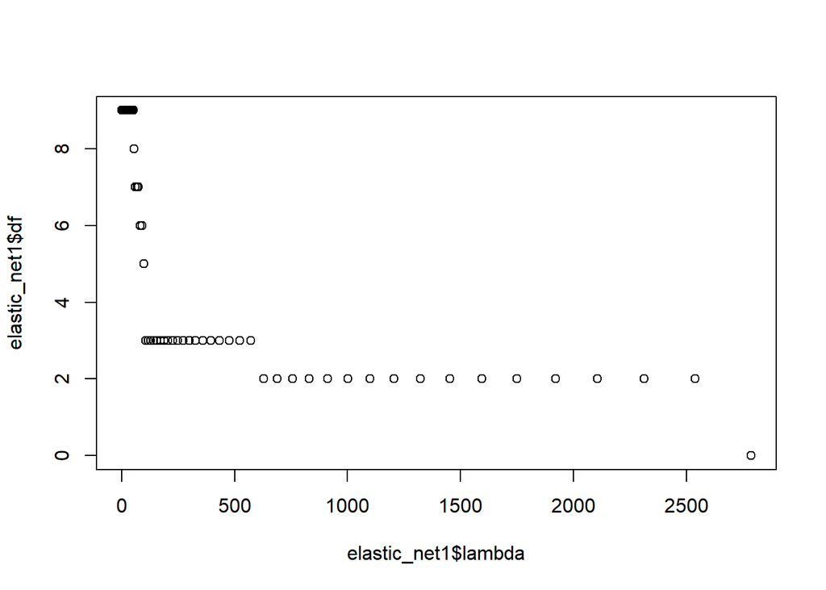

```r
plot(elastic_net1$lambda,elastic_net1$df)
```

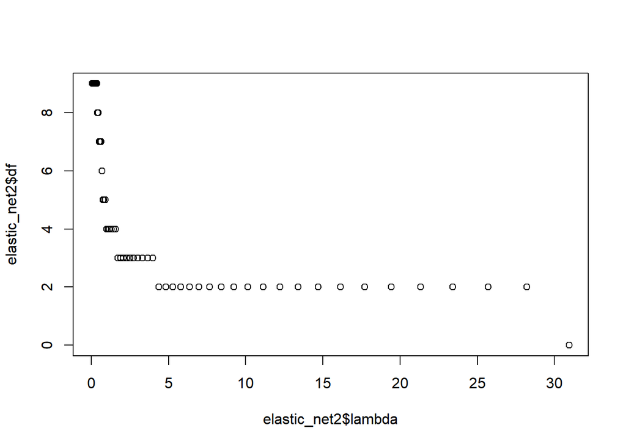

```r
plot(elastic_net2$lambda,elastic_net2$df)
```

7. Use plot(model) to view a plot of the coefficients as a function of lambda. –> see section 5

## Part 2: Cross validate and test

1. Split into train and test sets. Remember, we need 4 sets of data: train predictors, test predictors, train response, test response.

```r
index <- sample(x=1:nrow(x), size=.25*nrow(x))
test_x <- x[index,]
train_x <- x[-index,]
test_y <- y[index]
train_y <- y[-index]
```

2. Run ridge and lasso models on the training set and response using cv.glmnet with your choice of CV folds (I choose 5).

```r
ridge_cv <- cv.glmnet(train_x, train_y, alpha = 0, nfolds = 5)
lasso_cv <- cv.glmnet(train_x, train_y, alpha = 1, nfolds = 5)
```

3. Use model$lambda.min to extract lambda that minimizes cross validation error.

```r
ridge_cv$lambda.min
```

```
## [1] 2.873112
```

```r
lasso_cv$lambda.min
```

```
## [1] 1.606302
```

4. Plot both models - plot(model). Ridge CV:

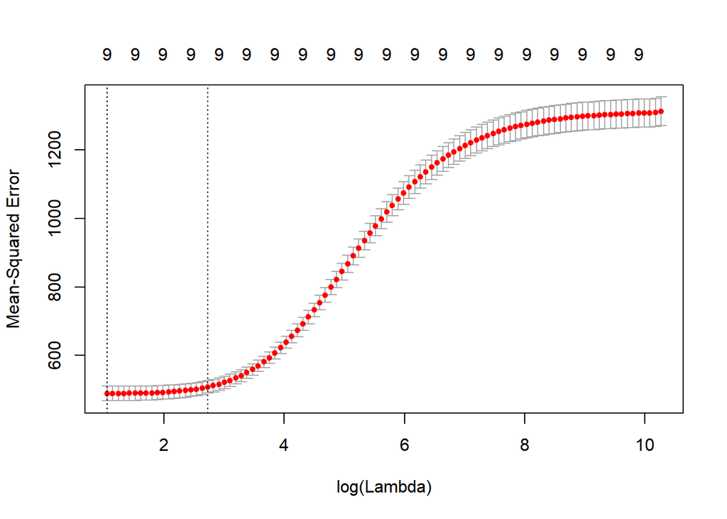

```r
plot(ridge_cv)
```

Lasso CV:

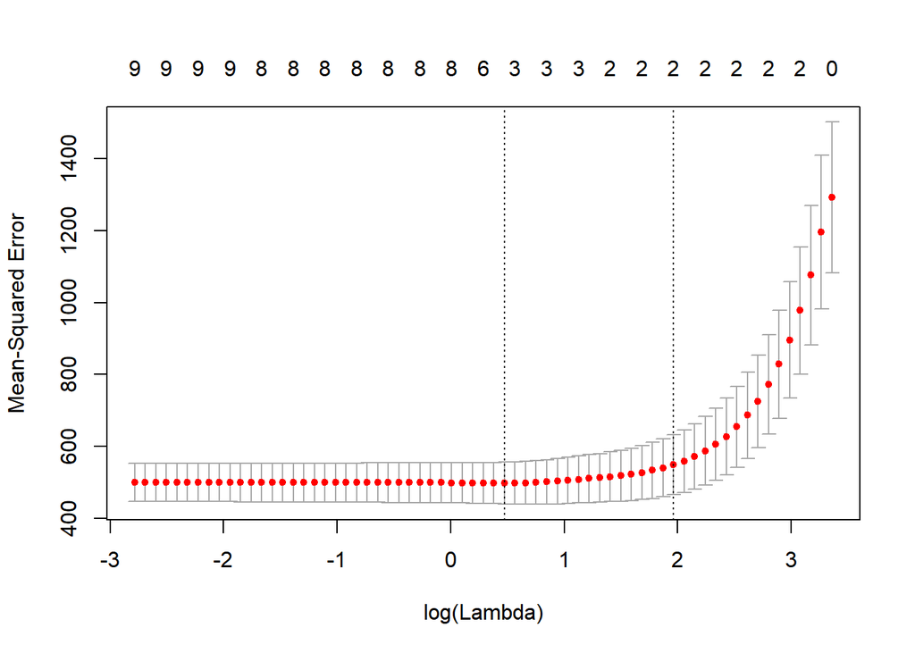

```r
plot(lasso_cv)
```

5. Predict response variable for test set using lambdas from question 3.

```r
y_hat_ridge <- predict(ridge_cv, s = ridge_cv$lambda.min, newx = test_x)
y_hat_lasso <- predict(lasso_cv, s = lasso_cv$lambda.min, newx = test_x)
```

6. Calculate test MSE. Which method predicts better?

```r
ridge_MSE <-mean((y_hat_ridge-test_y)^2)
lasso_MSE <-mean((y_hat_lasso-test_y)^2)
```

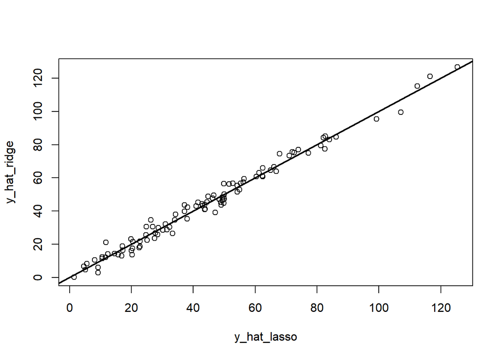

```r
plot(y_hat_lasso,y_hat_ridge)
abline(0,1,lwd=2)
```

And as we plot them with the real values, we can how similair both models are in their predictions:

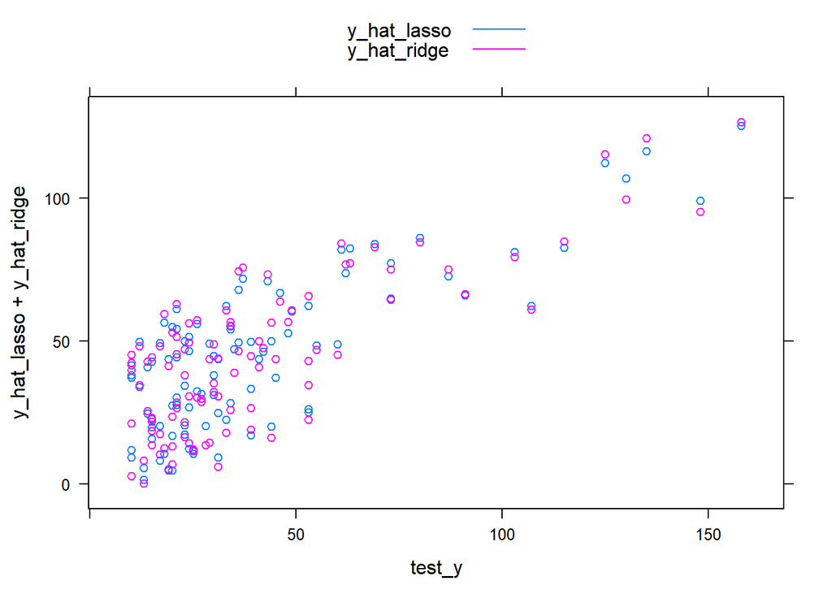

```r
library(lattice)
xyplot(y_hat_lasso + y_hat_ridge ~ test_y, ,auto.key = list(points = FALSE,lines = TRUE))
```

## Part 3: Explore PCR

In this exercise we will predict wine quality using different chemical aspects of the wine using the Wine data set. 1. Load Wine data - View data and variable classes. (I changed the file type to csv)

```r
wine_df <- read.csv('winequality.csv')
attach(wine_df)
str(wine_df)
```

```
## 'data.frame':    6497 obs. of  13 variables:
##  $ fixed.acidity       : num  7.4 7.8 7.8 11.2 7.4 7.4 7.9 7.3 7.8 7.5 ...
##  $ volatile.acidity    : num  0.7 0.88 0.76 0.28 0.7 0.66 0.6 0.65 0.58 0.5 ...
##  $ citric.acid         : num  0 0 0.04 0.56 0 0 0.06 0 0.02 0.36 ...
##  $ residual.sugar      : num  1.9 2.6 2.3 1.9 1.9 1.8 1.6 1.2 2 6.1 ...
##  $ chlorides           : num  0.076 0.098 0.092 0.075 0.076 0.075 0.069 0.065 0.073 0.071 ...
##  $ free.sulfur.dioxide : num  11 25 15 17 11 13 15 15 9 17 ...
##  $ total.sulfur.dioxide: num  34 67 54 60 34 40 59 21 18 102 ...
##  $ density             : num  0.998 0.997 0.997 0.998 0.998 ...
##  $ pH                  : num  3.51 3.2 3.26 3.16 3.51 3.51 3.3 3.39 3.36 3.35 ...
##  $ sulphates           : num  0.56 0.68 0.65 0.58 0.56 0.56 0.46 0.47 0.57 0.8 ...
##  $ alcohol             : num  9.4 9.8 9.8 9.8 9.4 9.4 9.4 10 9.5 10.5 ...
##  $ color               : Factor w/ 2 levels "red","white": 1 1 1 1 1 1 1 1 1 1 ...
##  $ quality             : int  5 5 5 6 5 5 5 7 7 5 ...
```

Is the data ready for modeling? I’ll check for missing values, recode color as a dummy and scale the data:

```r
wine_df[!complete.cases(wine_df),]
```

```
##  [1] fixed.acidity        volatile.acidity     citric.acid
##  [4] residual.sugar       chlorides            free.sulfur.dioxide
##  [7] total.sulfur.dioxide density              pH
## [10] sulphates            alcohol              color
## [13] quality
## <0 rows> (or 0-length row.names)
```

```r
wine_df$color <- ifelse(wine_df$color=='red', 1,0)
wine_df <- as.data.frame(scale(wine_df))
```

2. Run PCR without cross validation. Choose number of PCs (I’ll chose 10 components).

```r
library(pls)
require(pls)
pcr <- pcr(formula = quality ~ ., data = wine_df, scale = FALSE, ncomp = 10, validation = "none")
```

3. View output of PCR (use summary)

```r
summary(pcr)
```

```
## Data:    X dimension: 6497 12
##  Y dimension: 6497 1
## Fit method: svdpc
## Number of components considered: 10
## TRAINING: % variance explained
##          1 comps  2 comps  3 comps  4 comps  5 comps  6 comps  7 comps
## X         31.745    52.82    65.83    73.92    79.95    85.07    89.54
## quality    1.687    10.25    14.42    17.25    20.84    22.71    23.73
##          8 comps  9 comps  10 comps
## X          93.73    96.66     98.80
## quality    24.75    29.21     29.21
```

As we can see, the percent of variance explained increases with the number of components, as in the 7th components it reaches almost 90%.

4. Explore output options. View PCR scores and coefficients. I’ll use a Matrix to see the PCR coeffcieints for each component, and plot the pcr results:

```r
matrix(pcr$coefficients, 12, 10, dimnames = list(names(wine_df)[-13]))
```

```
##                              [,1]         [,2]         [,3]         [,4]
## fixed.acidity        -0.017102272 -0.067281264  0.006277672 -0.021938750
## volatile.acidity     -0.023879527 -0.030150812 -0.076981950 -0.114112895
## citric.acid           0.007599157 -0.030557711  0.065059398  0.110713988
## residual.sugar        0.016363984 -0.056828630 -0.085053352 -0.113251438
## chlorides            -0.019650869 -0.064028210 -0.062913065 -0.022412586
## free.sulfur.dioxide   0.022981834 -0.008191289 -0.033871660  0.028290154
## total.sulfur.dioxide  0.027481889 -0.007707702 -0.028422006  0.007788352
## density              -0.009450230 -0.112723400 -0.139103179 -0.151879381
## pH                   -0.012022122  0.023718201 -0.049743220  0.020825387
## sulphates            -0.018805850 -0.041064559 -0.026635901  0.081985362
## alcohol              -0.001315469  0.086259050  0.127482447  0.146372047
## color                -0.031316085 -0.045414856 -0.053380629 -0.050590388
##                             [,5]         [,6]        [,7]         [,8]
## fixed.acidity         0.01238323  0.050098215  0.01206224 -0.035519767
## volatile.acidity     -0.14721930 -0.062114216 -0.09526155 -0.069449327
## citric.acid           0.14633680  0.111483650  0.06362073  0.113480150
## residual.sugar       -0.03387647 -0.001317633  0.04217083  0.110987271
## chlorides            -0.16512572 -0.193574786 -0.19175078 -0.124765570
## free.sulfur.dioxide  -0.01012527  0.063852530  0.01500800 -0.008908081
## total.sulfur.dioxide -0.02298625  0.008413455 -0.01049935 -0.024466402
## density              -0.08620532 -0.093615087 -0.09631981 -0.094980798
## pH                    0.11813915  0.066363567  0.01287539  0.027783616
## sulphates             0.10647432  0.143058084  0.22144387  0.188428072
## alcohol               0.19387817  0.282918950  0.28516302  0.344895806
## color                -0.03349278 -0.014329103 -0.03657424 -0.042864472
##                              [,9]       [,10]
## fixed.acidity         0.025527358  0.03244886
## volatile.acidity     -0.270949978 -0.27268692
## citric.acid          -0.009181439 -0.01389809
## residual.sugar        0.161773615  0.16173608
## chlorides            -0.037863332 -0.03377105
## free.sulfur.dioxide   0.134673508  0.12975061
## total.sulfur.dioxide -0.155774423 -0.14876906
## density              -0.069344587 -0.06841929
## pH                    0.034573950  0.03832698
## sulphates             0.112940367  0.11227417
## alcohol               0.418720635  0.42217826
## color                 0.041715172  0.03659735
```

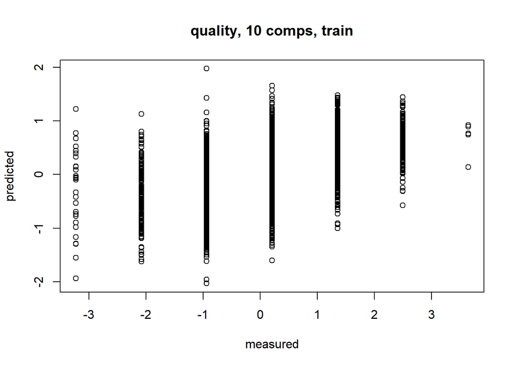

```r
plot(pcr)
```

## Part 4: Cross Validate and Test

1. Create test and train sets. Unlike other machine learning functions, PCR is under a regression setting and needs a train set which includes the response variable. The test set, however, needs to be split into predictors and response sets.

```r
set.seed(1234)
index <- sample(1:nrow(wine_df), size=.2*nrow(wine_df))
wine_train <- wine_df[-index,]
wine_test <- wine_df[index,]
wine_test_y <- wine_test$quality
wine_test_x <- wine_test[,-13]
```

2. Run PCR with cross validation.

```r
pcr_cv <- pcr(formula = quality ~ ., data = wine_train, scale = FALSE, validation = "CV")
```

3. Use summary to view PCR output -> what is the optimal number of principal components?

```r
summary(pcr_cv)
```

```
## Data:    X dimension: 5198 12
##  Y dimension: 5198 1
## Fit method: svdpc
## Number of components considered: 12
##
## VALIDATION: RMSEP
## Cross-validated using 10 random segments.
##        (Intercept)  1 comps  2 comps  3 comps  4 comps  5 comps  6 comps
## CV          0.9972   0.9905   0.9417   0.9212   0.9025   0.8851   0.8737
## adjCV       0.9972   0.9905   0.9416   0.9212   0.9024   0.8850   0.8735
##        7 comps  8 comps  9 comps  10 comps  11 comps  12 comps
## CV      0.8693   0.8635   0.8360    0.8361    0.8359    0.8346
## adjCV   0.8694   0.8634   0.8358    0.8359    0.8358    0.8344
##
## TRAINING: % variance explained
##          1 comps  2 comps  3 comps  4 comps  5 comps  6 comps  7 comps
## X         31.552    52.63    65.63    73.83    79.93    85.09    89.57
## quality    1.371    10.83    14.76    18.18    21.45    23.50    24.30
##          8 comps  9 comps  10 comps  11 comps  12 comps
## X          93.74    96.64     98.79     99.79    100.00
## quality    25.33    30.14     30.15     30.20     30.51
```

4. Show output in a plot using validationplot() function -> can you tell what the optimal number of principal components is?

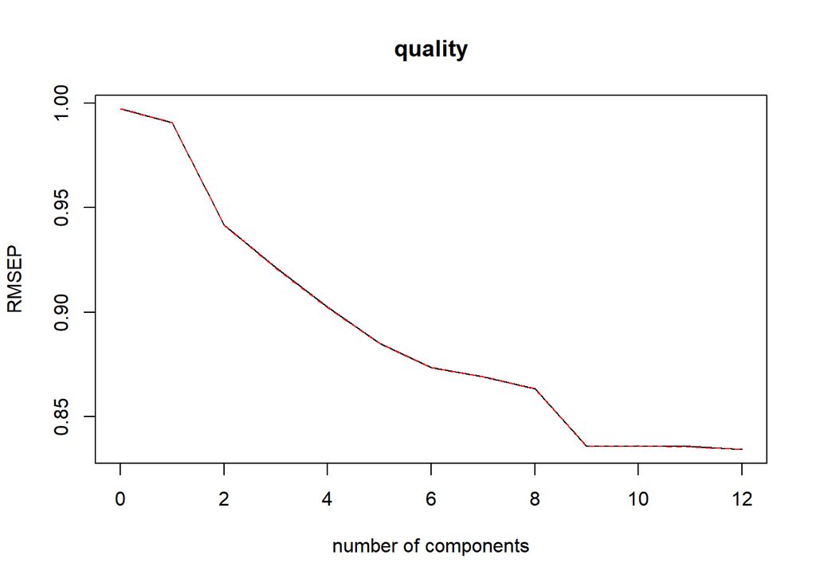

```r
validationplot(pcr_cv)
```

8 components explained 94% of variablity and can also be used as the optimal numberm though, though 9 components explain more without a big chance in the error.

5. Calculate test MSE for the optimal PC’s as well as the last PC.

```r
pcr_all <- predict(pcr_cv, wine_test_x, ncomp=12)
mean((pcr_all-wine_test_y)^2)
```

```
## [1] 0.7551776
```

```r
pcr_9 <- predict(pcr_cv, wine_test_x, ncomp=9)
mean((pcr_9-wine_test_y)^2)
```

```
## [1] 0.76262
```

```r
pcr_8 <- predict(pcr_cv, wine_test_x, ncomp=8)
mean((pcr_8-wine_test_y)^2)
```

```
## [1] 0.8037395
```

THE END.